# Tutorial 12 - Machine Learning

# SHAP Dependence Plots vs. Partial Dependence Plots

SHAP dependence plots and PDPs both show how a predictor relates to the response, but they answer slightly different questions and can diverge when predictors are correlated. A SHAP dependence plot shows the SHAP value for one predictor (y-axis) vs. the predictor’s actual value (x-axis), with points colored by a second predictor to reveal interactions. Below we plot SHAP dependence for MAT and MAP, then compare the MAT SHAP dependence plot to the MAT PDP side by side.

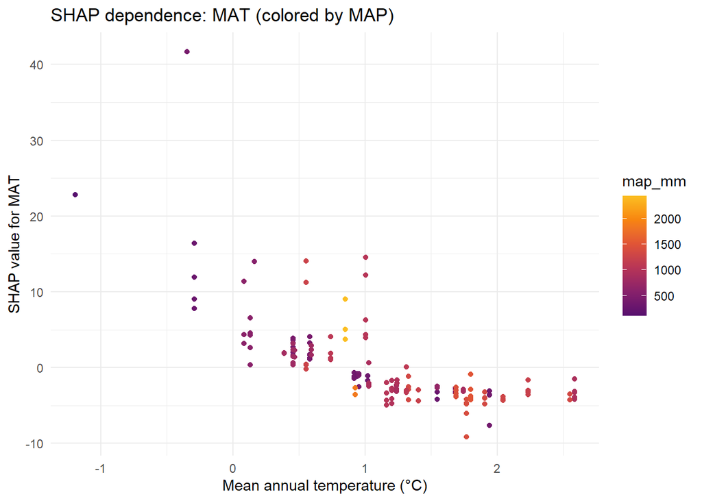

```r
sv_dependence(shap_rf, v = "mat_c", color_var = "map_mm") +
  labs(x = "Mean annual temperature (°C)", y = "SHAP value for MAT",
       title = "SHAP dependence: MAT (colored by MAP)") +
  theme_minimal()
```

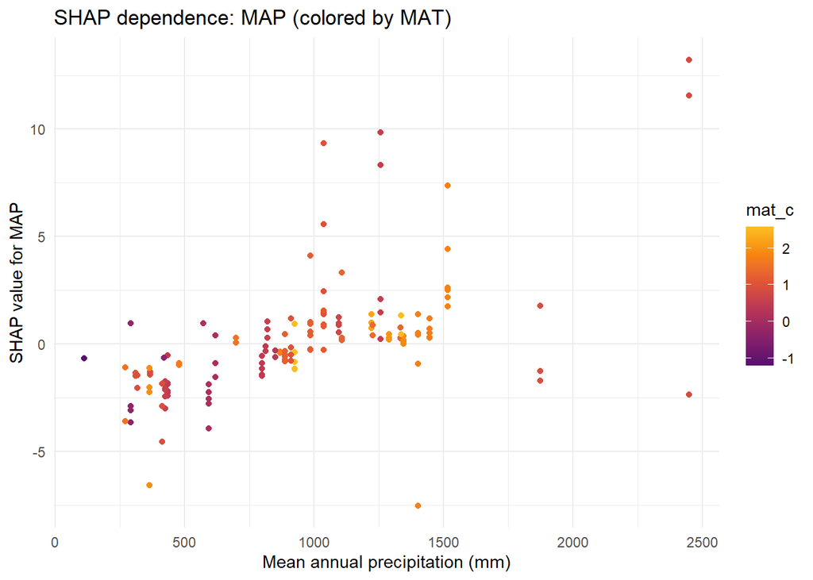

```r
sv_dependence(shap_rf, v = "map_mm", color_var = "mat_c") +
  labs(x = "Mean annual precipitation (mm)", y = "SHAP value for MAP",
       title = "SHAP dependence: MAP (colored by MAT)") +
  theme_minimal()
```

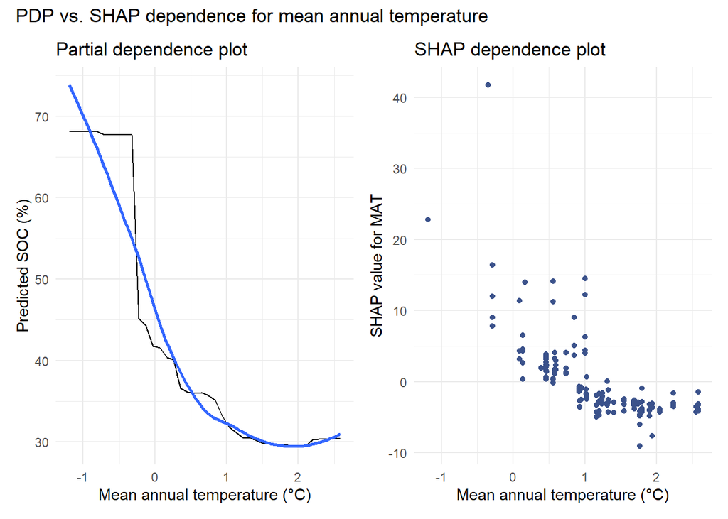

```r
pdp_mat <- pdp::partial(rf_fit, pred.var = "mat_c", train = train,
                         grid.resolution = 40)

p_pdp <- autoplot(pdp_mat, smooth = TRUE) +
  labs(x = "Mean annual temperature (°C)", y = "Predicted SOC (%)",
       title = "Partial dependence plot") +
  theme_minimal()

p_shap <- sv_dependence(shap_rf, v = "mat_c", color_var = NULL) +
  labs(x = "Mean annual temperature (°C)", y = "SHAP value for MAT",
       title = "SHAP dependence plot") +
  theme_minimal()

p_pdp + p_shap +
  plot_annotation(title = "PDP vs. SHAP dependence for mean annual temperature")
```

### Task 16

Following the example above for `mat_c`, generate a side-by-side PDP and SHAP dependence plot for `bulk_density`.

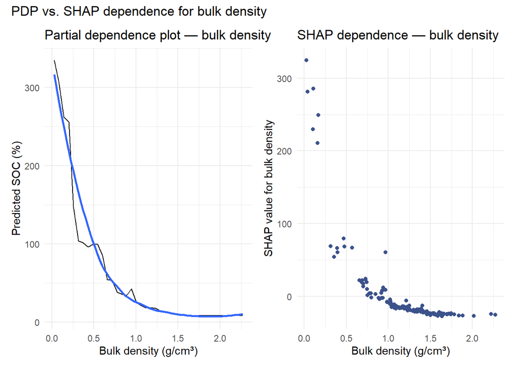

```r
pdp_bd <- pdp::partial(
  rf_fit,
  pred.var = "bulk_density",
  train = train,
  grid.resolution = 40
)

p_pdp_bd <- autoplot(pdp_bd, smooth = TRUE) +
  labs(
    x = "Bulk density (g/cm³)",
    y = "Predicted SOC (%)",
    title = "Partial dependence plot — bulk density"
  ) +
  theme_minimal()

p_shap_bd <- sv_dependence(
  shap_rf,
  v = "bulk_density",
  color_var = NULL
) +
  labs(
    x = "Bulk density (g/cm³)",
    y = "SHAP value for bulk density",
    title = "SHAP dependence — bulk density"
  ) +
  theme_minimal()

p_pdp_bd + p_shap_bd +
  plot_annotation(title = "PDP vs. SHAP dependence for bulk density")
```

1. Do the two methods show the same general shape?

Yes.

2. Color the SHAP dependence plot by `mat_c`. Does the effect of bulk density appear to vary with temperature? Describe any interaction pattern you see and suggest an ecological mechanism.

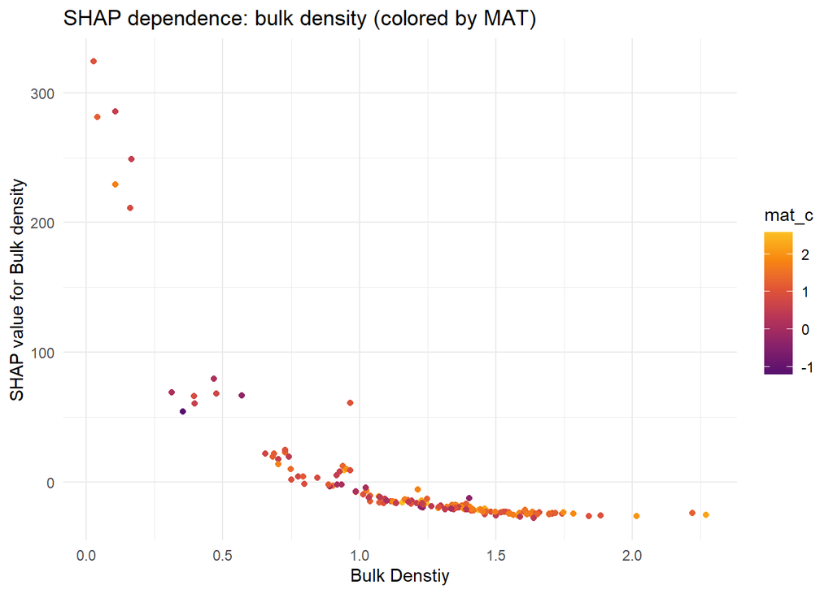

```r
sv_dependence(shap_rf, v = "bulk_density", color_var = "mat_c") +
  labs(x = "Bulk Denstiy", y = "SHAP value for Bulk density",
       title = "SHAP dependence: bulk density (colored by MAT)") +
  theme_minimal()
```

I cannot see a relationship between bulk density and mat_c. It would make sense that temprature would effect the relationship between bulk density and soil organic carbon given that temperature affects the rate of chemical processes, but I can’t see it in this plot.

# Cross-Model Comparison

SHAP is model-agnostic. Both `shap_rf` and `shap_xgb` are already computed. Here we compare mean absolute SHAP values across both models to test whether our ecological interpretation depends on algorithm choice. Findings that are robust to algorithm choice are generally considered more trustworthy. This property is sometimes called **algorithmic stability**.

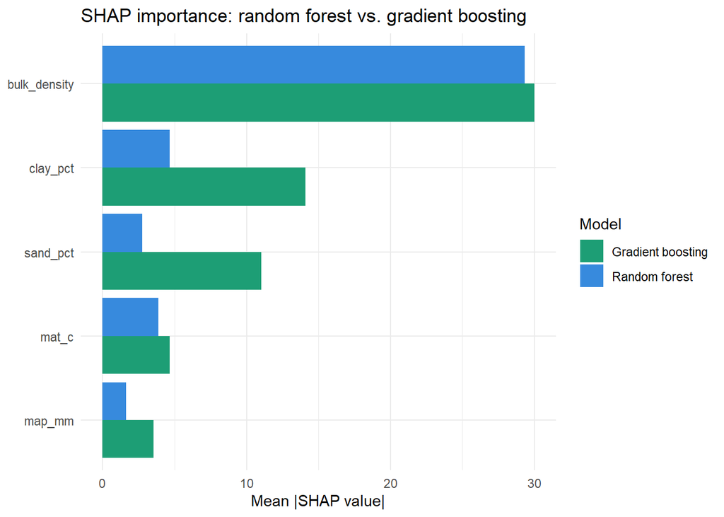

```r
imp_rf  <- colMeans(abs(shap_rf$S))
imp_xgb <- colMeans(abs(shap_xgb$S))

data.frame(
  predictor = predictors,
  rf        = imp_rf[predictors],
  xgb       = imp_xgb[predictors]
) %>%
  pivot_longer(-predictor, names_to = "model", values_to = "mean_abs_shap") %>%
  mutate(predictor = fct_reorder(predictor, mean_abs_shap, .fun = max),
         model     = recode(model, rf = "Random forest", xgb = "Gradient boosting")) %>%
  ggplot(aes(x = mean_abs_shap, y = predictor, fill = model)) +
  geom_col(position = "dodge") +
  scale_fill_manual(values = c("Random forest" = "#378ADD",
                               "Gradient boosting" = "#1D9E75")) +
  labs(x = "Mean |SHAP value|", y = NULL, fill = "Model",
       title = "SHAP importance: random forest vs. gradient boosting") +
  theme_minimal()
```

### Task 17

Do the two models agree on which predictors are most important? Identify any predictors ranked substantially differently across models. When would you be *more* concerned about algorithmic instability?

They both rank the predictors similarly, with the exception of sand_pct and mat_c. I would be more concerned about algarithmic instability if the larger predictors were ranked differently.

# Limitations and Responsible Use of SHAP

```r
rf_fit2 <- ranger(
  formula       = soc_pct ~ mat_c + map_mm + clay_pct + sand_pct + bulk_density,
  data          = train,
  num.trees     = 500,
  mtry          = 3,
  min.node.size = 5,
  keep.inbag    = TRUE,
  seed          = 999
)

ks_rf2   <- kernelshap(rf_fit2, X = train[, predictors], bg_X = train[, predictors])
```

```
## Exact Kernel SHAP values
```

[output not shown]

```r
shap_rf2 <- shapviz(ks_rf2)

data.frame(
  predictor    = predictors,
  shap_seed605 = shap_rf$S[1, predictors],
  shap_seed999 = shap_rf2$S[1, predictors]
) %>%
  mutate(difference = shap_seed605 - shap_seed999) %>%
  arrange(desc(abs(difference)))
```

```
##                 predictor shap_seed605 shap_seed999 difference
## map_mm             map_mm    11.562827    13.572131 -2.0093043
## bulk_density bulk_density    66.302007    67.957672 -1.6556645
## mat_c               mat_c     5.025759     3.482851  1.5429078
## clay_pct         clay_pct    -3.753611    -4.057148  0.3035364
## sand_pct         sand_pct     2.263136     1.966738  0.2963984
```

### Task 18

The table above compares SHAP values for a single observation across two random forest fits that differ only in their random seed. (a) How large are the differences? Are they ecologically meaningful?

The differences are small and not ecologically meaningful.

2. Implement a robustness check: refit the random forest three more times with seeds 111, 222, and 333. For each fit, compute SHAP values on the training set and extract the SHAP value for `bulk_density` for observation 1. Report the mean and standard deviation across all five fits (including seeds 605 and 999). Are there any conclusions you can be confident about?

```r
rf_fit3 <- ranger(
  formula       = soc_pct ~ mat_c + map_mm + clay_pct + sand_pct + bulk_density,
  data          = train,
  num.trees     = 500,
  mtry          = 3,
  min.node.size = 5,
  keep.inbag    = TRUE,
  seed          = 111
)

ks_rf3   <- kernelshap(rf_fit3, X = train[, predictors], bg_X = train[, predictors])
```

```
## Exact Kernel SHAP values
```

[output not shown]

```r
shap_rf3 <- shapviz(ks_rf3)

data.frame(
  predictor    = predictors,
  shap_seed605 = shap_rf$S[1, predictors],
  shap_seed111 = shap_rf3$S[1, predictors]
) %>%
  mutate(difference = shap_seed605 - shap_seed111) %>%
  arrange(desc(abs(difference)))
```

```
##                 predictor shap_seed605 shap_seed111 difference
## mat_c               mat_c     5.025759     3.151103  1.8746556
## bulk_density bulk_density    66.302007    67.068674 -0.7666667
## sand_pct         sand_pct     2.263136     1.851995  0.4111411
## map_mm             map_mm    11.562827    11.196245  0.3665819
## clay_pct         clay_pct    -3.753611    -4.081767  0.3281555
```

```r
rf_fit4 <- ranger(
  formula       = soc_pct ~ mat_c + map_mm + clay_pct + sand_pct + bulk_density,
  data          = train,
  num.trees     = 500,
  mtry          = 3,
  min.node.size = 5,
  keep.inbag    = TRUE,
  seed          = 222
)

ks_rf4   <- kernelshap(rf_fit4, X = train[, predictors], bg_X = train[, predictors])
```

```
## Exact Kernel SHAP values
```

[output not shown]

```r
shap_rf4 <- shapviz(ks_rf4)

data.frame(
  predictor    = predictors,
  shap_seed605 = shap_rf$S[1, predictors],
  shap_seed222 = shap_rf4$S[1, predictors]
) %>%
  mutate(difference = shap_seed605 - shap_seed222) %>%
  arrange(desc(abs(difference)))
```

```
##                 predictor shap_seed605 shap_seed222 difference
## mat_c               mat_c     5.025759     3.473858  1.5519011
## sand_pct         sand_pct     2.263136     1.294129  0.9690070
## clay_pct         clay_pct    -3.753611    -4.518645  0.7650341
## bulk_density bulk_density    66.302007    67.064102 -0.7620948
## map_mm             map_mm    11.562827    12.299524 -0.7366964
```

```r
rf_fit5 <- ranger(
  formula       = soc_pct ~ mat_c + map_mm + clay_pct + sand_pct + bulk_density,
  data          = train,
  num.trees     = 500,
  mtry          = 3,
  min.node.size = 5,
  keep.inbag    = TRUE,
  seed          = 333
)

ks_rf5   <- kernelshap(rf_fit5, X = train[, predictors], bg_X = train[, predictors])
```

```
## Exact Kernel SHAP values
```

[output not shown]

```r
shap_rf5 <- shapviz(ks_rf5)

data.frame(
  predictor    = predictors,
  shap_seed605 = shap_rf$S[1, predictors],
  shap_seed333 = shap_rf5$S[1, predictors]
) %>%
  mutate(difference = shap_seed605 - shap_seed333) %>%
  arrange(desc(abs(difference)))
```

```
##                 predictor shap_seed605 shap_seed333 difference
## bulk_density bulk_density    66.302007    68.850889  -2.548882
## sand_pct         sand_pct     2.263136     3.829654  -1.566517
## clay_pct         clay_pct    -3.753611    -5.274944   1.521333
## mat_c               mat_c     5.025759     3.842363   1.183396
## map_mm             map_mm    11.562827    12.400340  -0.837513
```

```r
bd_shap_values <- c(
  shap_rf$S[1, "bulk_density"],   # seed 605
  shap_rf2$S[1, "bulk_density"],  # seed 999
  shap_rf3$S[1, "bulk_density"],  # seed 111
  shap_rf4$S[1, "bulk_density"],  # seed 222
  shap_rf5$S[1, "bulk_density"]   # seed 333
)

bd_shap_values
```

```
## bulk_density bulk_density bulk_density bulk_density bulk_density
##     66.30201     67.95767     67.06867     67.06410     68.85089
```

```r
mean_bd <- mean(bd_shap_values)
sd_bd   <- sd(bd_shap_values)

mean_bd
```

```
## [1] 67.44867
```

```r
sd_bd
```

```
## [1] 0.9788292
```

the SHAP value for bulk density for observtion one is stable. The random seed is not responsible for the interpetation of the relationship between bulk sensity and soil organic carbon.